# Project: Who is going to control the US senate?

HH

10/18/2014

# Part 1: Introduction

Who is going to control the US Senate? Currently the Democratic Party controls the Senate, but elections for the United States Senate will be held on November 4, 2014. 36 of the 100 seats will be contested. 21 of those are currently held by Democrats and 15 by Republicans.

Knowing the answer of this question before the election is important for both parties because it allows them to focus their resources in the senate races that will allow them to win the control of the Senate. It is important for the voters because it may prompt them to actively participate on the races.

Who controls the US Senate will define american politics in the next years. It may weaken or strengthen the current presidency.

# Part 2: Data

The data was collected by the Huffington Post. It can be downloaded in this [link](http://elections.huffingtonpost.com/2014/senate-outlook/huffpost-2014-senate-forecast.csv) It represents a daily estimation of who is going to win every race taking data from every public released poll and quantifying uncertainty from different sources.

> - The time remaining between the current snapshot and the election.
> - The possibility that the polls could be wrong or that some sort of major event could shake up a race in ways that the current polls can’t measure.
> - The proportion of “undecided” voters in the polls. If the undecided proportion is high relative to the expected margin between the candidates, the outcome of that race must be less certain. [source](http://elections.huffingtonpost.com/2014/senate-outlook)

Every case is the result of an individual forecast for every senate race. We have the date of the poll, the number of senate seats, the probability of a republican victory and the probability of a democratic victory. For the purpose of our analysis we only use the latest estimation for each state.

There are 36 variables. One for each senate race. Every variable is a categorical variable with two levels. Probability of republican victory and probability of democratic victory. The interesting part of the project is that those variables need to be combined into a single categorical variable with two levels. Probability of republican control of the house and probability of democratic control of the house.

The inference is done assuming we had the elections today. Since the voters preferences can change in time, you cannot generalize this result to the day of the elections. This is an observational study since we are using data that has been collected without our intervention controlling any variables. For that reason we cannot establish causality.

# Part 3: Exploratory data analysis

```r
polldata = read.csv("huffpost-2014-senate-forecast.csv");
head(polldata);
```

```
##         date state seat r.prob d.prob
## 1 2014-07-01    AK    1   32.6   67.4
## 2 2014-07-01    AL    1   99.0    1.0
## 3 2014-07-01    AR    1   48.3   51.7
## 4 2014-07-01    CO    1   47.4   52.6
## 5 2014-07-01    DE    1    1.0   99.0
## 6 2014-07-01    GA    1   51.1   48.9
```

```r
dim(polldata);
```

```
## [1] 4625    5
```

```r
names(polldata);
```

```
## [1] "date"   "state"  "seat"   "r.prob" "d.prob"
```

Looking at the means gives us a preliminary idea that the republican party is doing better than the democratic party on these 36 seats.

```r
summary(polldata$r.prob);
```

```
##    Min. 1st Qu.  Median    Mean 3rd Qu.    Max.
##    0.20    6.60   55.90   56.33   99.00  100.00
```

```r
summary(polldata$d.prob);
```

```
##    Min. 1st Qu.  Median    Mean 3rd Qu.    Max.
##    0.00    1.00   44.10   43.68   93.40   99.80
```

We can see how the country(US) preferences have evolved over time.

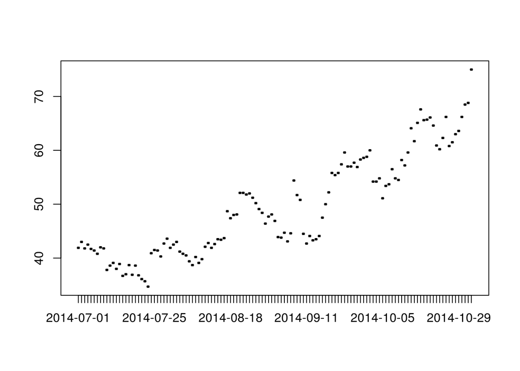

```r
uspoll = subset(polldata, state == 'US');
plot(uspoll$date, uspoll$r.prob, type="o");
```

The more recent forecast for every seat.

```r
read.csv("seatprobs.csv");
```

```
##   index   AK1 AL1   AR1   CO1  DE1   GA1   HI1   IA1  ID1   IL1  KS1  KY1
## 1     1 0.675   1 0.578 0.538 0.01 0.648 0.002 0.565 0.99 0.018 0.51 0.69
##     LA1   MA1   ME1   MI1   MN1   MS1 MT1   NC1   NE1   NH1   NJ1   NM1
## 1 0.808 0.007 0.996 0.358 0.032 0.929 0.9 0.402 0.993 0.394 0.041 0.019
##    OK1  OK2   OR1  RI1   SC1  SC2   SD1   TN1   TX1   VA1   WV1  WY1
## 1 0.99 0.99 0.014 0.01 0.968 0.99 0.895 0.989 0.989 0.019 0.974 0.99
```

# Part 4: Inference

## Check conditions

1. Independence.
- We have the results for the state polls that can be used to calculate a single probability for who controls the senate adding the individuals. So n = 1, and we can conclude that this sample is independent of the other (non-existent) samples.
2. Sample size/skew. ${ np≥10 and n(1−p)≥10 }$
- Since n = 1, we don’t have the necessary number of samples to use a theoretical method. We will use simulation to determine the proportion.

*I am not using Hypthesis Testing, Confidenence Itervals, Chi-Square or ANOVA since those methods are not aplicable to the data available and the research question.*

## Inference by Simulation

We have the probabilities of the individual state elections. We are going to run a random simulation using the individual probabilities for the states to determine if the sum of the states is enough to win the senate.

Step 1. Determine the probabilities of a republican victory on every state.

Step 2. Simulate one election.

Step 2.1. For every state do the following:

Step 2.1.1. throw a 100 side dice.

Step 2.1. if the number of republican victories + 30 >= 51 consider this election as republican candidate controls senate.

Step 3. Repeat Step 2; 10,000 times. Count the number of times that the republican party controls the senate to calculate the proportion.

### Simulation algorithm

I attempted to do this simulation using R, but it turned up beyond my capabilities. So I decided to implement the simulation using Perl and the data analysis and inference using R.

```
#!/usr/bin/perl -w

use strict;

open my $handle, '<', "huffpost-2014-senate-forecast.csv";
chomp(my @lines = <$handle>);
close $handle;

my %states = ();
foreach my $line (@lines) {

    my ($date, $state, $seat, $rprob, $dprob) = split(/,/,$line);

    next if $date eq "date";
    next if $state eq "US";

    $states{ $state . $seat } = $rprob / 100;

}

my @keys = sort { $a cmp $b } keys %states;

sub seatprobs {
    print "index";
    foreach my $state ( @keys ) {
        print ",$state";
    }
    print "\n1";
    foreach my $state ( @keys ) {
        print ",$states{$state}";
    }
    print "\n";
}

sub make_election($) {
    my $i = shift;
    print $i;
    my $count = 0;
    foreach my $state ( @keys ) {
        my $p = $states{$state};
        if (rand(1) < $p) {
            print ",r";
            $count++;
        }
        else {
            print ",d";
        }
    }
    print ",$count\n";
}


print "election";
foreach my $state ( @keys ) {
    printf ",$state";
}
print ",seats\n";
for(my $i = 1; $i <= 10000; $i++) {
    make_election($i);
}
print "states=".int(@keys);
```

## Simulation results analysis

```r
elections = read.csv("elections.csv");
head(elections);
```

```
##   election AK1 AL1 AR1 CO1 DE1 GA1 HI1 IA1 ID1 IL1 KS1 KY1 LA1 MA1 ME1 MI1
## 1        1   r   r   r   d   d   r   d   r   r   d   d   r   r   d   r   d
## 2        2   r   r   r   r   d   d   d   r   r   d   r   r   r   d   r   d
## 3        3   d   r   r   d   d   r   d   d   r   d   d   r   r   d   r   d
## 4        4   r   r   r   d   d   r   d   d   r   d   d   r   r   d   r   d
## 5        5   d   r   r   r   d   r   d   d   r   d   d   r   d   d   r   d
## 6        6   r   r   r   r   d   r   d   r   r   d   r   r   r   d   r   d
##   MN1 MS1 MT1 NC1 NE1 NH1 NJ1 NM1 OK1 OK2 OR1 RI1 SC1 SC2 SD1 TN1 TX1 VA1
## 1   d   r   r   d   r   r   d   r   r   r   d   d   r   r   r   r   r   d
## 2   d   r   r   r   r   r   d   d   r   r   d   d   r   r   r   r   r   d
## 3   d   r   r   r   r   r   d   d   r   r   d   d   r   r   r   r   r   d
## 4   d   r   r   r   r   d   d   d   r   r   d   d   r   r   r   r   r   d
## 5   d   r   r   d   r   d   d   d   r   r   d   d   r   r   r   r   r   d
## 6   d   r   r   r   r   d   d   d   r   r   d   d   r   r   r   r   r   d
##   WV1 WY1 seats
## 1   r   r    23
## 2   r   r    24
## 3   r   r    21
## 4   r   r    21
## 5   r   r    19
## 6   r   r    24
```

```r
seats=elections$seats+30;
summary(seats);
```

```
##    Min. 1st Qu.  Median    Mean 3rd Qu.    Max.    NA's
##   45.00   50.00   51.00   51.27   52.00   57.00       1
```

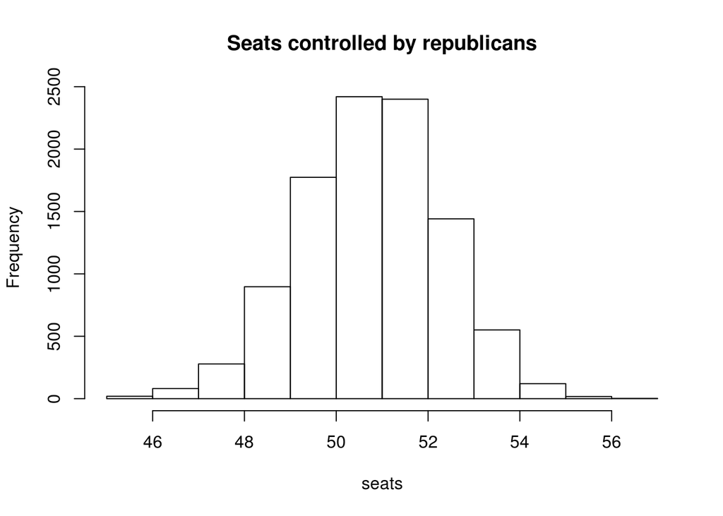

```r
hist(seats, breaks=14, main="Seats controlled by republicans");
```

```r
fr=table(seats);
fr
```

```
## seats
##   45   46   47   48   49   50   51   52   53   54   55   56   57
##    2   17   81  278  897 1774 2420 2400 1441  551  120   17    2
```

Finally the probability that the republicans control the senate is

```r
pRep=sum(fr[7:13])/10000;
pDem=sum(fr[1:6])/10000;
sprintf("pRep=%.4f, pDem=%.4f, total=%.4f", pRep, pDem, pRep+pDem);
```

```
## [1] "pRep=0.6951, pDem=0.3049, total=1.0000"
```

# Part 5: Conclusion

I came out with the idea of using simulation to determine the who controls the senate while watching the news. When I started digging into the subject it was evident that it was the method of choice for several forecasters. Some of them build beautiful interactive sites with this information and their models are much more sophisticated than mine. For example the NYT model contemplate the case of independent candidate Greg Orman that has promised he will align with who ever gets the majority, thus changing the control of the house.

Some examples:

- [New York Times](http://www.nytimes.com/newsgraphics/2014/senate-model/) Republicans 70% chance.
- [Politico](http://www.politico.com/2014-election/predictions/senate/) No simulation was done.
- [Sabato’s Crystal Ball](http://www.centerforpolitics.org/crystalball/2014-senate/) No simulaton was done.
- [538](http://fivethirtyeight.com/interactives/senate-forecast/) Republicans 62.2%
- [Real clear politics](http://www.realclearpolitics.com/epolls/2014/senate/2014_elections_senate_map.html)No simulation was done.
- [Huffington Post](http://elections.huffingtonpost.com/2014/senate-outlook)66 % Republicans.

Future ideas:

- Keep trends of the proportion as the election gets closer to see which party is moving ahead.
- Be able to do what-if scenarios on the simulation to determine where money and energy should be spent.
- Analyze differences in forecasts. Find the factors that influence the differences between forecasting models.

# Apendix

```r
head(elections, n =50);
```

[output not shown]

[output cut: 138 more lines]